[figure not shown]

# Being able to create clusters is a powerful (and delicious!) tool that will make you a stronger data scientist

# Review question:

## What's the difference between supervised and unsupervised learning?

[figure not shown]

**Classification** - create a model to predict which group a point belongs to

**Clustering** - find groups that exist in the data already

# Ask yourself:

## How could unsupervised learning or clustering be useful?

### Helpful uses for clustering:

- Find items with similar behavior (users, products, voters, etc)
- Market segmentation
- Understand complex systems
- Discover meaningful categories for your data
- Reduce the number of classes by grouping (e.g. bourbons, scotches -> whiskeys)
- Reduce the dimensions of your problem
- Pre-processing! Create labels for supervised learning

# Great. Clustering is useful.

-

# Any ideas how to algorithmically tell which groups are different?

[figure not shown]

# K Means

.

### My First<sup>TM</sup> Clustering Algorithm

1. Pick a value for k (the number of clusters to create)
2. Initialize k 'centroids' (starting points) in your data
3. Create your clusters. Assign each point to the nearest centroid.
4. Make your clusters better. Move each centroid to the center of its cluster.
5. Repeat steps 3-4 until your centroids converge.

# K Means

1. Pick a value for k (the number of clusters to create)

[figure not shown]

# K Means

1. Pick a value for k (the number of clusters to create)
2. Initialize k 'centroids' (starting points) in your data

[figure not shown]

# K Means

1. Pick a value for k (the number of clusters to create)
2. Initialize k 'centroids' (starting points) in your data
3. Assign each point to the nearest centroid. These are your 'clusters'.

[figure not shown]

# K Means

1. Pick a value for k (the number of clusters to create)
2. Initialize k 'centroids' (starting points) in your data
3. Assign each point to the nearest centroid. These are your clusters.
4. Make your clusters better. Move each centroid to the center of its cluster.

[figure not shown]

# K Means

1. Pick a value for k (the number of clusters to create)
2. Initialize k 'centroids' (starting points) in your data
3. Assign each point to the nearest centroid. These are your clusters.
4. Make your clusters better. Move each centroid to the center of its cluster.
5. Repeat steps 3-4 until your centroids converge.

[figure not shown]

# K Means

1. Pick a value for k (the number of clusters to create)
2. Initialize k 'centroids' (starting points) in your data
3. Assign each point to the nearest centroid. These are your clusters.
4. Make your clusters better. Move each centroid to the center of its cluster.
5. Repeat steps 3-4 until your centroids converge.

[figure not shown]

# K Means

1. Pick a value for k (the number of clusters to create)
2. Initialize k 'centroids' (starting points) in your data
3. Assign each point to the nearest centroid. These are your clusters.
4. Make your clusters better. Move each centroid to the center of its cluster.
5. Repeat steps 3-4 until your centroids converge.

[figure not shown]

# K Means

1. Pick a value for k (the number of clusters to create)
2. Initialize k 'centroids' (starting points) in your data
3. Assign each point to the nearest centroid. These are your clusters.
4. Make your clusters better. Move each centroid to the center of its cluster.
5. Repeat steps 3-4 until your centroids converge.

[figure not shown]

# K Means

1. Pick a value for k (the number of clusters to create)
2. Initialize k 'centroids' (starting points) in your data
3. Assign each point to the nearest centroid. These are your clusters.
4. Make your clusters better. Move each centroid to the center of its cluster.
5. Repeat steps 3-4 until your centroids converge.

[figure not shown]

# K Means

1. Pick a value for k (the number of clusters to create)
2. Initialize k 'centroids' (starting points) in your data
3. Assign each point to the nearest centroid. These are your clusters.
4. Make your clusters better. Move each centroid to the center of its cluster.
5. Repeat steps 3-4 until your centroids converge.

[figure not shown]

# Let's practice a toy example by hand. Take a 1-dimensional array of numbers:

```python
arr = [2, 5, 6, 8, 12, 15, 18, 28, 30]
```

Pick k=3 random start centroids and let the other points fall into clusters based on the closest centroid. Then, reassign your centroids based on the mean value of your cluster and repeat the process.

Check with your neighbors. Do you have the same clusters? Why or why not?

#### K Means is a powerful algorithm, but different starting points may give you different clusters. You won't necessarily get an optimal cluster.

# Metrics for K Means

**Inertia** -- sum of squared errors for each cluster

- low inertia = dense cluster

**Silhouette Score** -- measure of how far apart clusters are

- high Silhouette Score = clusters are well separated

# How do I know which K to pick?

Sometimes you have good context:

- I need to create 3 profiles for marketing to target

Other times you have to figure it out:

- My scatter plots show 2 linearly separable clusters

More on this later this morning.

# Group Practice

Let's do some clustering with the iris dataset.

```python
df = pd.read_csv("assets/datasets/iris.csv")
df.head(5)
```

|  | SepalLength | SepalWidth | PetalLength | PetalWidth | Name |
| --- | --- | --- | --- | --- | --- |
| 0 | 5.1 | 3.5 | 1.4 | 0.2 | Iris-setosa |
| 1 | 4.9 | 3.0 | 1.4 | 0.2 | Iris-setosa |
| 2 | 4.7 | 3.2 | 1.3 | 0.2 | Iris-setosa |
| 3 | 4.6 | 3.1 | 1.5 | 0.2 | Iris-setosa |
| 4 | 5.0 | 3.6 | 1.4 | 0.2 | Iris-setosa |

Our dataset has the categorical column Name in it, so we'll to convert this columns to numeric data for the k-means algorithm to accept it. Typically, that would take a simple if statement to for all of the values in the categorical column. For this dataset, the name column has Iris-setosa, Iris-virginica, and Iris-versicolor as attributes.

```python
def name_to_numeric(x):
    if x=='Iris-setosa':
        return 1
    if x=='Iris-virginica':
        return 2
    if x=='Iris-versicolor':
        return 3
```

```python
df['name_num'] = df['Name'].apply(name_to_numeric)
del df['Name']
```

```python
df.head(2)
```

|  | SepalLength | SepalWidth | PetalLength | PetalWidth | name_num |
| --- | --- | --- | --- | --- | --- |
| 0 | 5.1 | 3.5 | 1.4 | 0.2 | 1 |
| 1 | 4.9 | 3.0 | 1.4 | 0.2 | 1 |

Now let's plot the data to see the distributions:

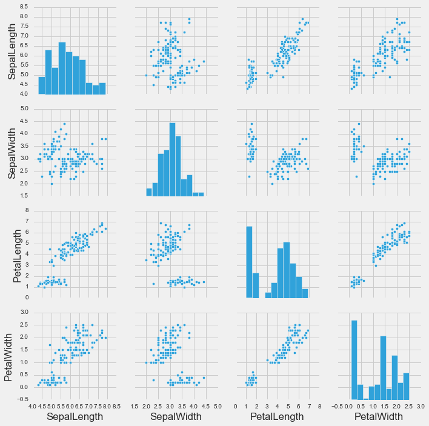

```python
cols = df.columns[:-1]
sns.pairplot(df[cols])
```

Next, since each of our features have different units and ranges, let's do some preprocessing:

```python
X_scaled = preprocessing.MinMaxScaler().fit_transform(df)
```

```python
pd.DataFrame(X_scaled, columns=df.columns).describe()
```

|  | SepalLength | SepalWidth | PetalLength | PetalWidth | name_num |
| --- | --- | --- | --- | --- | --- |
| count | 150.000000 | 150.000000 | 150.000000 | 150.000000 | 150.000000 |
| mean | 0.428704 | 0.439167 | 0.467571 | 0.457778 | 0.500000 |
| std | 0.230018 | 0.180664 | 0.299054 | 0.317984 | 0.409616 |
| min | 0.000000 | 0.000000 | 0.000000 | 0.000000 | 0.000000 |
| 25% | 0.222222 | 0.333333 | 0.101695 | 0.083333 | 0.000000 |
| 50% | 0.416667 | 0.416667 | 0.567797 | 0.500000 | 0.500000 |
| 75% | 0.583333 | 0.541667 | 0.694915 | 0.708333 | 1.000000 |
| max | 1.000000 | 1.000000 | 1.000000 | 1.000000 | 1.000000 |

Now that we've formatted our data and understand it's structures, we can finally go ahead and cluster.

We're going to set k at two given behavior we were seeing above in our graphs.

```python
k = 2
kmeans = cluster.KMeans(n_clusters=k)
kmeans.fit(X_scaled)
```

```
KMeans(copy_x=True, init='k-means++', max_iter=300, n_clusters=2, n_init=10,
    n_jobs=1, precompute_distances='auto', random_state=None, tol=0.0001,
    verbose=0)
```

We can use Scikit's built-in functions to determine the locations of the labels, centroids, and cluster inertia:

```python
labels = kmeans.labels_
centroids = kmeans.cluster_centers_
inertia = kmeans.inertia_

print labels
print centroids
print inertia
```

```
[1 1 1 1 1 1 1 1 1 1 1 1 1 1 1 1 1 1 1 1 1 1 1 1 1 1 1 1 1 1 1 1 1 1 1 1 1
 1 1 1 1 1 1 1 1 1 1 1 1 1 0 0 0 0 0 0 0 0 0 0 0 0 0 0 0 0 0 0 0 0 0 0 0 0
 0 0 0 0 0 0 0 0 0 0 0 0 0 0 0 0 0 0 0 0 0 0 0 0 0 0 0 0 0 0 0 0 0 0 0 0 0
 0 0 0 0 0 0 0 0 0 0 0 0 0 0 0 0 0 0 0 0 0 0 0 0 0 0 0 0 0 0 0 0 0 0 0 0 0
 0 0]
[[ 0.545       0.36333333  0.6620339   0.65666667  0.75      ]
 [ 0.19611111  0.59083333  0.07864407  0.06        0.        ]]
18.3936882816
```

And to compute the clusters' silhouette coefficient:

```python
metrics.silhouette_score(X_scaled, labels, metric='euclidean')
```

```
0.66528122999569039
```

...and we're done! You've completed your first clustering analysis.

Let's see how it looks. First, let's put the labels columns into our dataframe

```python
df['label'] = labels
df.head()
```

|  | SepalLength | SepalWidth | PetalLength | PetalWidth | name_num | label |
| --- | --- | --- | --- | --- | --- | --- |
| 0 | 5.1 | 3.5 | 1.4 | 0.2 | 1 | 1 |
| 1 | 4.9 | 3.0 | 1.4 | 0.2 | 1 | 1 |
| 2 | 4.7 | 3.2 | 1.3 | 0.2 | 1 | 1 |
| 3 | 4.6 | 3.1 | 1.5 | 0.2 | 1 | 1 |
| 4 | 5.0 | 3.6 | 1.4 | 0.2 | 1 | 1 |

Let's plot each cluster in a different color. Seaborn has a 'hue' parameter we can use for this.

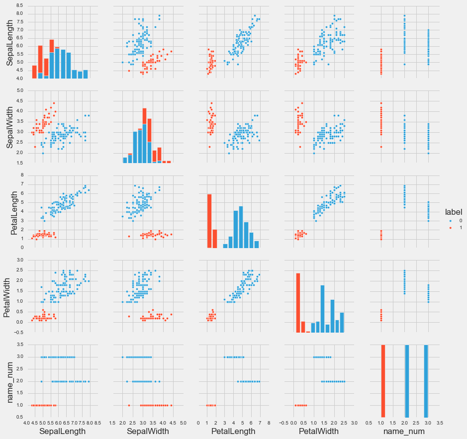

```python
cols = df.columns[:-1]
sns.pairplot(df, x_vars=cols, y_vars= cols, hue='label')
```

Just for comparison, here's the data colored by name of the plant.

Go back up and change the number of clusters to 3, or 4. See how those clusters compare to the data below.

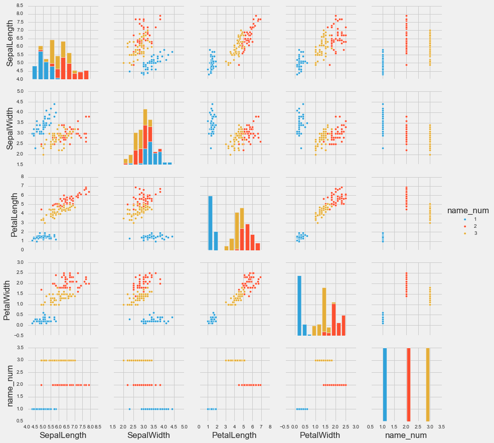

```python
sns.pairplot(df, x_vars=cols, y_vars= cols, hue='name_num')
```

# Independent Practice: Perform a K-Means Analysis (15 minutes)

Now that we've walked through the process of clustering, it's time to try it on your own. We're going to be working with the mtcars data set, and your job is to cluster these cars to understand their various attributes.

The dataset contains a listing of 33 different cars from a used car dealership - your task is the cluster the cars to discover their groupings. For each car, you have a variety of technical information related to the car's performance.

Open the data and starter code and try to work through both exercises with a partner. Do your best!

# Wrap Up

Discuss the two variables you chose and explain how your plots demonstrate the data.

Check: What is Clustering?

Check: How is Clustering Different from Classification?

# Resources

- [Sci-Kit Learn Clustering Overview](http://scikit-learn.org/stable/modules/clustering.html#k-means)
- [SKLearn K-Means Documentation](http://scikit-learn.org/stable/modules/generated/sklearn.cluster.KMeans.html#sklearn.cluster.KMeans)
- [SKLearn Clustering Code - See _k_init__ for explanation of k++ centroid selection](https://github.com/scikit-learn/scikit-learn/blob/51a765a/sklearn/cluster/k_means_.py#L769)
- [Clustering Tutorial](http://home.deib.polimi.it/matteucc/Clustering/tutorial_html/)
- [Wikipedia's Deep Dive on Clustering](https://en.wikipedia.org/wiki/K-means_clustering)
- [An excellent blog from Galvanize on K-Means Clustering](http://www.galvanize.com/blog/introduction-k-means-cluster-analysis/#.V9aXqpOAOkp)